# Course Project - Submission

Fernando Almeida Barbalho

22 de abril de 2019

## Downloading the file

The analysis done here use the following dataset

*Training Dataset* https://d396qusza40orc.cloudfront.net/predmachlearn/pml-training.csv

The R instructions bellow download the file and attibute it to a dataframe.

The columns related to stastics metrics were excluded.

```r
library(readr)
library(dplyr)

download.file("https://d396qusza40orc.cloudfront.net/predmachlearn/pml-training.csv", destfile = "pml-training.csv")
pml_training <- read_csv("pml-training.csv")

pml_train_trabalho<-pml_training %>% select(-c(12:36,50:59,69:83,87:101,103:112, 125:139, 141:150))

#download.file("https://d396qusza40orc.cloudfront.net/predmachlearn/pml-testing.csv", destfile = "pml-testing.csv")

pml_testing <- read_csv("pml-testing.csv")

pml_test_trabalho<-pml_testing %>% select(-c(12:36,50:59,69:83,87:101,103:112, 125:139, 141:150))
```

## Choosing the method

As there are many possibilities to apply ML algorithms, this work will be focused on those ones that were presented in the **Practical Machine Learning course**.

In this sense, the dataset was trained using the following methods:

- rpart
- rf
- treebag
- gbm

Some of the methods presented on the course were not put in consideration:

- forecasting: the problem is not related to predict future values on a time series
- clusters: the categories were given

I executed the following lines to generate the models, evaluate the time spent in training the models and also to evaluate their accurancies:

```
library(caret)
library(lubridate)

#the variables 2:7 are not considered on the model
pml_train_model <- pml_train_trabalho[,-c(1:7)]
inTrain<- createDataPartition(y= pml_train_model$classe, p=0.7, list = FALSE)

pml_train_model<- pml_train_model[inTrain,]



# prepare training scheme: 30 resamples from 10 folders with 3 repeats
control <- trainControl(method="repeatedcv", number=10, repeats=3)

set.seed(13)
ini_rpatr<- now()
model_rpart<- train(classe~.,method = "rpart", data = pml_train_model, trControl = control)
end_rpatr<- now()
print(end_rpatr- ini_rpatr)



set.seed(13)
ini_rf <- now()
model_rf<- train(classe~.,method = "rf", data = pml_train_model, trControl = control)
end_rf <- now()
print(end_rf- ini_rf)


set.seed(13)
ini_bag<-now()
model_treebag<- train(classe~.,method = "treebag", data = pml_train_model, trControl = control)
end_bag<-now()
print(end_bag-ini_bag)


set.seed(13)
ini_gbm<-now()
model_gbm<- train(classe~.,method = "gbm", data = pml_train_model, trControl = control)
end_gbm <- now()
print(end_gbm - ini_gbm)




# collect resamples
results <- resamples(list(rpart=model_rpart,
                          rf=model_rf,
                          treebag=model_treebag,
                          gbm=model_gbm))
pos_obj<- which(ls() %in% c("pml_training","pml_train_trabalho","pml_testing","pml_test_trabalho","pml_train_model"))

save (list= "results", file="results.RData")
save (list="model_treebag", file="model_treebag.RData")
save (list="inTrain", file = "inTrain.RData")
```

As it can be seen above, the columns related to the windows of the trainings were not included in the models.

See also that the strategy for cross-validation used for each model included 30 resample, with 10 folders with 3 repeats, each.

Bellow is described a summary of the results associated with the resamples over the four models.

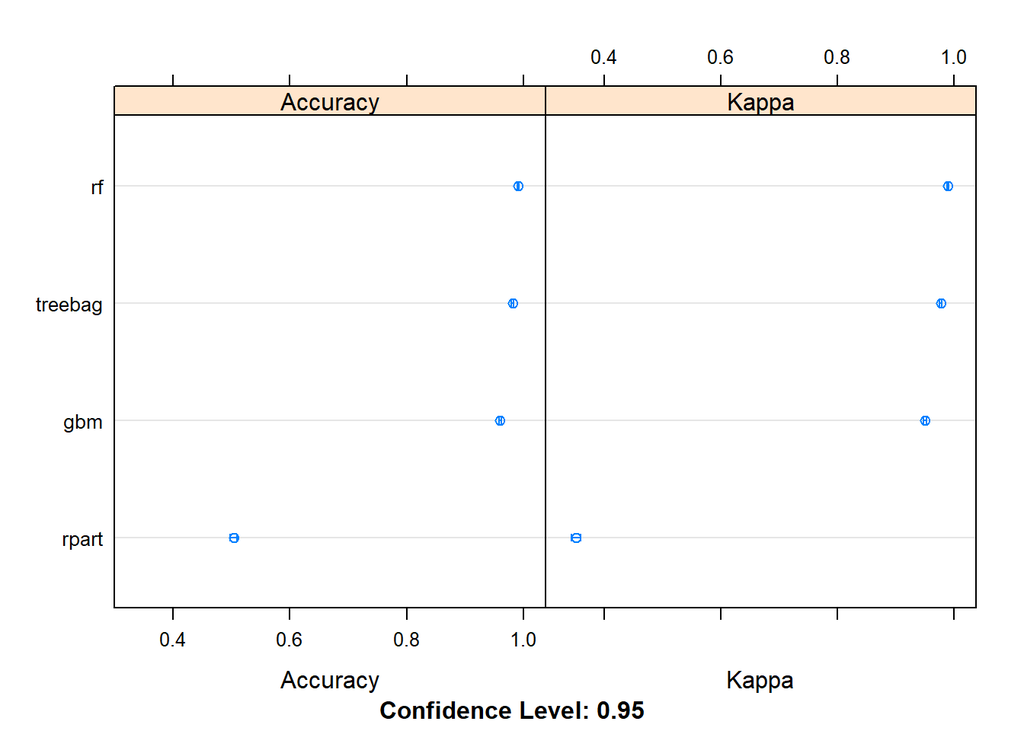

```r
library(mlbench)
library(caret)

load("results.RData")

dotplot(results)
```

As shown in the graph above, the accurancies of the methods **bgm**, **rf** and **treebag** are very close to each other with values near 100% in a 95% confidence level. So, the key to choose the best method will be the time consumption to train and run the models. The graph bellow shows these measures.

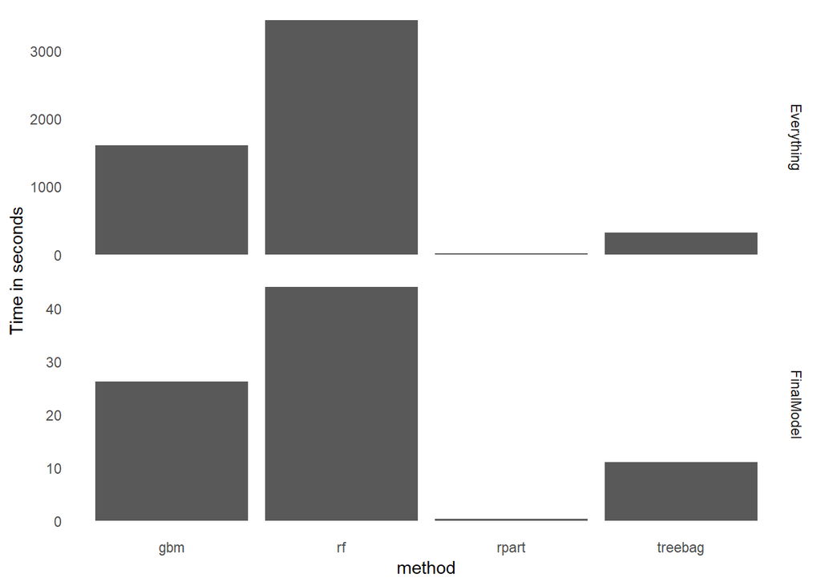

```r
library(ggplot2)
library(tidyr)


timing <- results$timings

timing %>%
  mutate( method=row.names(timing)) %>%
  select(method, Everything,FinalModel) %>%
  gather(key = Type_Measure, value= Value, -method) %>%
  ggplot(aes(x= method, y=Value)) +
  geom_col() +
  facet_grid("Type_Measure ~.", scales = "free_y") +
  theme_minimal() +
  theme(
    panel.grid = element_blank()
  )+
  ylab("Time in seconds")
```

The final step on this project is estimate the expected out of sample error. I used a randomic subset of the train set to test this measurement. Please, see the following lines of code

```r
load("model_treebag.RData")
load("inTrain.RData")

set.seed(1972)


pred1<- predict(model_treebag$finalModel,pml_training[-inTrain,])

confusionMatrix(pred1, factor(pml_training$classe[-inTrain]))
```

```
## Confusion Matrix and Statistics
##
##           Reference
## Prediction    A    B    C    D    E
##          A 1663   20    2    7    1
##          B    7 1111   15    6    6
##          C    4    6 1001    8    3
##          D    0    2    8  942    9
##          E    0    0    0    1 1063
##
## Overall Statistics
##
##                Accuracy : 0.9822
##                  95% CI : (0.9784, 0.9854)
##     No Information Rate : 0.2845
##     P-Value [Acc > NIR] : < 2.2e-16
##
##                   Kappa : 0.9774
##  Mcnemar's Test P-Value : 7.829e-05
##
## Statistics by Class:
##
##                      Class: A Class: B Class: C Class: D Class: E
## Sensitivity            0.9934   0.9754   0.9756   0.9772   0.9824
## Specificity            0.9929   0.9928   0.9957   0.9961   0.9998
## Pos Pred Value         0.9823   0.9703   0.9795   0.9802   0.9991
## Neg Pred Value         0.9974   0.9941   0.9949   0.9955   0.9961
## Prevalence             0.2845   0.1935   0.1743   0.1638   0.1839
## Detection Rate         0.2826   0.1888   0.1701   0.1601   0.1806
## Detection Prevalence   0.2877   0.1946   0.1737   0.1633   0.1808
## Balanced Accuracy      0.9932   0.9841   0.9857   0.9867   0.9911
```

The Confusion Matrix above shows that is expected an accurancy out of sample very close to the one measured with the train set. The error is estimated in less than 2% This accurancy combined to a very fast method to evaluate data gathered from real use cases, demonstrates that the **treebag** final model can be used in almost real time applications that measures the performance of gym sutdents.

Now it´s the moment to use this model to predict the results over the 20 cases of the test set. See below

```r
library(DT)

set.seed(1972)


pml_test_model <- pml_test_trabalho[,-c(1:7,60)]


pred_test<- predict(model_treebag$finalModel,pml_test_model)

pml_test_trabalho$classe <- pred_test


DT::datatable(pml_test_trabalho[,c(60,61)], rownames = FALSE)
```

| problem_id | classe |
| --- | --- |
| 1 | B |
| 2 | A |
| 3 | A |
| 4 | A |
| 5 | A |
| 6 | E |
| 7 | D |
| 8 | B |
| 9 | A |
| 10 | A |

[output cut: 10 more lines]